# Associative Analysis of CT images

The goal is to run a correlative or associative study between CT scan images and patients' age and contrast ( applied or not).

```python
import pandas as pd
import numpy as np
import os
import torchvision
import torch
import libtiff
from pydicom import dcmread
from libtiff import TIFF
import matplotlib.pyplot as plt
from torchvision import transforms
```

```python
data_description = pd.read_csv("overview.csv")
```

```python
data_description.head()
```

|  | Unnamed: 0 | Age | Contrast | ContrastTag | raw_input_path | id | tiff_name | dicom_name |
| --- | --- | --- | --- | --- | --- | --- | --- | --- |
| 0 | 0 | 60 | True | NONE | ../data/50_50_dicom_cases\Contrast\00001 (1).dcm | 0 | ID_0000_AGE_0060_CONTRAST_1_CT.tif | ID_0000_AGE_0060_CONTRAST_1_CT.dcm |
| 1 | 1 | 69 | True | NONE | ../data/50_50_dicom_cases\Contrast\00001 (10).dcm | 1 | ID_0001_AGE_0069_CONTRAST_1_CT.tif | ID_0001_AGE_0069_CONTRAST_1_CT.dcm |
| 2 | 2 | 74 | True | APPLIED | ../data/50_50_dicom_cases\Contrast\00001 (11).dcm | 2 | ID_0002_AGE_0074_CONTRAST_1_CT.tif | ID_0002_AGE_0074_CONTRAST_1_CT.dcm |
| 3 | 3 | 75 | True | NONE | ../data/50_50_dicom_cases\Contrast\00001 (12).dcm | 3 | ID_0003_AGE_0075_CONTRAST_1_CT.tif | ID_0003_AGE_0075_CONTRAST_1_CT.dcm |
| 4 | 4 | 56 | True | NONE | ../data/50_50_dicom_cases\Contrast\00001 (13).dcm | 4 | ID_0004_AGE_0056_CONTRAST_1_CT.tif | ID_0004_AGE_0056_CONTRAST_1_CT.dcm |

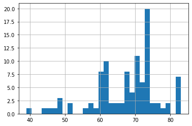

```python
data_description.Age.hist(bins = 30)
```

Age column is pretty skewed. A suggestible idea would be to create a categorical data to deal with age. From histogram, probably best idea would be create a variable to indicate whether the patient is above or below 70 years old.

```python
def age_cat(row):
    if row['Age'] > 70:
        return "Above"
    else:
        return "Below"
data_description['Age_Cat'] = data_description.apply(lambda row: age_cat(row), axis = 1)
```

```python
data_description.Age_Cat.value_counts()
```

```
Below    52
Above    48
Name: Age_Cat, dtype: int64
```

Our new target variable, is relatively balanced, therefore we would not have balance problem when training a model based on this target. Let's take a look at other target variable, even though in this specific analysis I am not going to use them for training.

```python
data_description.Contrast.value_counts()
```

```
True     50
False    50
Name: Contrast, dtype: int64
```

Balanced regarding contrast distribution

```python
from torchvision import utils
from torch.utils.data import Dataset, DataLoader
```

```python
data_transforms =  transforms.Compose([
        transforms.RandomHorizontalFlip(),
        transforms.Normalize([0.485, 0.456, 0.406], [0.229, 0.224, 0.225])
    ])

class CT_Images(Dataset):

    def __init__(self, csv_file_root, tiff_root, dicom_root, transform = None):

        self.csv_file = pd.read_csv(csv_file_root)
        self.tiff_root = tiff_root
        self.dicom_root = dicom_root
        self.transform = transform



    def __len__(self):
        return len(self.csv_file)



    def __getitem__(self, index):

        if torch.is_tensor(index):
            index = index.to_list()


        image_name_tiff = os.path.join(self.tiff_root, self.csv_file.tiff_name[index])

        """
        If one is interested in loading DICOM data, it can be loaded and returned.
        However due to our interest only in pixel data, this can be unnecessary
        and we can do our analysis with only TIFF images
        """

        image_name_dicom = os.path.join(self.dicom_root, self.csv_file.dicom_name[index])
        #dicom_image = dcmread(image_name_dicom)
        image_TIFF = TIFF.open(image_name_tiff)
        for image in image_TIFF.iter_images():
            x = np.array(image)
        """
        Since Images are 1-channeled, we have to make them suitable for later training
        by pre-trained models. Therefore, repeat them through 3-channels.
        """
        x = np.repeat(x[..., np.newaxis], 3, -1)
        x = x.transpose(2,1,0)


        contrast_image = self.csv_file.Contrast[index]
        string_contrast = "With Contrast" if contrast_image else "No Contrast"
        age_category = 1 if self.csv_file.Age[index] >= 70 else 0
        x = torch.from_numpy(x)
        if self.transform:
            x = self.transform(x)


        return x, age_category, string_contrast
```

```python
CT_images_dataset = CT_Images("overview.csv", "tiff_images", "dicom_dir", data_transforms)
train_set, test_set = torch.utils.data.random_split(CT_images_dataset, [80, 20])
image_datasets = {'train': train_set, 'test':test_set}

dataloaders = {x: torch.utils.data.DataLoader(image_datasets[x], batch_size=8,
                                             shuffle=True, num_workers=2)
              for x in ['train', 'test']}

dataset_sizes = {x: len(image_datasets[x]) for x in ['train', 'test']}
class_names = ['Below 70 Years Old', 'Above 70 years Old']
```

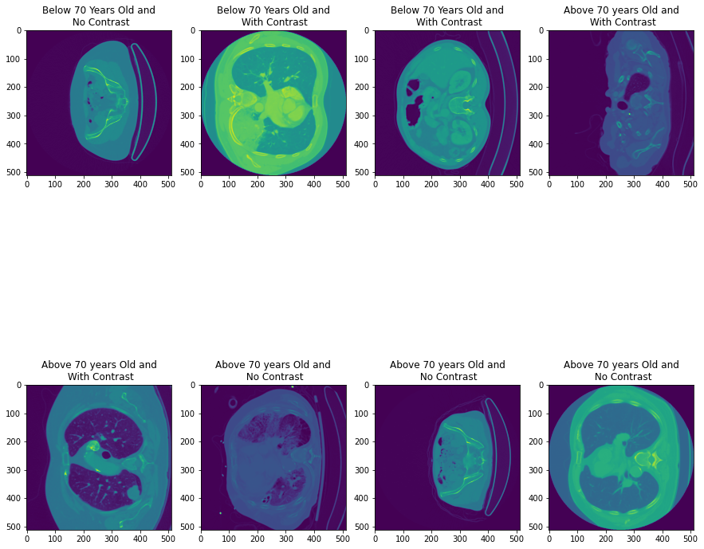

```python
"Plotting a random sample of CT Scan Images"
images, classes, contrast_classes = next(iter(dataloaders['train']))
fig = plt.subplots(2,4, figsize=(15,15))
for i in range(8):
    plt.subplot(2,4,i+1)
    plt.title(class_names[classes[i]] + " and\n " + contrast_classes[i])
    plt.imshow(images[i][1].numpy().reshape(512,512))
```

# Training and Fine-Tuning

```python
device = torch.device("cuda:0" if torch.cuda.is_available() else "cpu")
import copy
def train_model(model, criterion, optimizer, scheduler, num_epochs=25):

    chosen_model_weights = copy.deepcopy(model.state_dict())
    best_accuracy = 0.0

    for epoch in range(num_epochs):
        print('Epoch {}/{}'.format(epoch, num_epochs - 1))
        print('-' * 10)

        for phase in ['train', 'test']:
            if phase == 'train':
                model.train()
            else:
                model.eval()

            running_loss = 0.0
            running_corrects = 0

            for inputs, labels,_ in dataloaders[phase]:
                inputs = inputs.to(device, dtype=torch.float)
                labels = labels.to(device, dtype=torch.long)

                optimizer.zero_grad()

                with torch.set_grad_enabled(phase == 'train'):
                    outputs = model(inputs)
                    _, preds = torch.max(outputs, 1)
                    loss = criterion(outputs, labels)

                    if phase == 'train':
                        loss.backward()
                        optimizer.step()


                running_loss += loss.item() * inputs.size(0)
                running_corrects += torch.sum(preds == labels.data)
            if phase == 'train':
                scheduler.step()

            epoch_loss = running_loss / dataset_sizes[phase]
            epoch_accuracy = running_corrects.double() / dataset_sizes[phase]

            print('{} Loss: {:.4f} Accuracy: {:.4f}'.format(
                phase, epoch_loss, epoch_accuracy))

            """
            We save the model's weight with best accuracy
            for later use.
            """
            if phase == 'test' and epoch_accuracy > best_accuracy:
                best_accuracy = epoch_accuracy
                chosen_model_weights = copy.deepcopy(model.state_dict())

        print()
    print('Best Test Accuracy: {:4f}'.format(best_accuracy))
    model.load_state_dict(chosen_model_weights)
    return model
```

```python
import torch.nn as nn
import torch.optim as optim
from torch.optim import lr_scheduler
from torchvision import datasets, models, transforms

"Getting Pre-Trained Resnet Model"
model_resnet = models.resnet18(pretrained=True)
model_features = model_resnet.fc.in_features

"Changing Last Layer to Suit Two Class Training"
model_resnet.fc = nn.Linear(model_features, 2)
model_resnet = model_resnet.to(device)

criterion = nn.CrossEntropyLoss()
optimizer_model = optim.SGD(model_resnet.parameters(), lr=0.001, momentum=0.9)
"Decaying learning rate, since we use a pre-trianed model"
exp_lr_scheduler = lr_scheduler.StepLR(optimizer_model, step_size=8, gamma=0.1)
```

```python
model_resnet = train_model(model_resnet, criterion, optimizer_model, exp_lr_scheduler, num_epochs=25)
```

```
----------
train Loss: 0.8000 Accuracy: 0.4625
test Loss: 0.6792 Accuracy: 0.5500

----------
train Loss: 0.6648 Accuracy: 0.5875
test Loss: 0.6549 Accuracy: 0.5000

----------
train Loss: 0.5877 Accuracy: 0.6750
test Loss: 0.6457 Accuracy: 0.5000

----------
train Loss: 0.5549 Accuracy: 0.7250
test Loss: 0.5120 Accuracy: 0.8000

----------
train Loss: 0.4620 Accuracy: 0.8375
test Loss: 0.5603 Accuracy: 0.8000

----------
train Loss: 0.4197 Accuracy: 0.8000
test Loss: 0.5167 Accuracy: 0.7500

----------
train Loss: 0.3407 Accuracy: 0.8750
test Loss: 0.4602 Accuracy: 0.8000

----------
train Loss: 0.3984 Accuracy: 0.8250
test Loss: 0.4336 Accuracy: 0.8000

----------
train Loss: 0.2553 Accuracy: 0.9375
test Loss: 0.3920 Accuracy: 0.9000

----------
train Loss: 0.2140 Accuracy: 0.9750
test Loss: 0.4360 Accuracy: 0.7500

```

[output cut: 46 more lines]

```
test Loss: 0.3801 Accuracy: 0.9500

----------
train Loss: 0.2123 Accuracy: 0.9625
test Loss: 0.3975 Accuracy: 0.8500

----------
train Loss: 0.1750 Accuracy: 0.9875
test Loss: 0.4032 Accuracy: 0.8000

----------
train Loss: 0.2700 Accuracy: 0.8875
test Loss: 0.3998 Accuracy: 0.9500

Best Test Accuracy: 0.950000
```

```python
"""
Using some images from test dataset
to illustrate performance of model
"""
def visualize_model(model, num_images = 8):
    was_training = model.training
    model.eval()
    images_so_far = 0
    fig = plt.figure(figsize=(20,20))

    with torch.no_grad():
        for i, (inputs, labels, contrast_class) in enumerate(dataloaders['test']):
            inputs = inputs.to(device,dtype=torch.float)
            labels = labels.to(device,dtype=torch.long)

            outputs = model(inputs)
            _, preds = torch.max(outputs, 1)


            for j in range(inputs.size()[0]):
                images_so_far += 1
                ax = plt.subplot(num_images//2, 2, images_so_far)
                ax.axis('off')
                ax.set_title('Predicted:{}\n True Class:{} \n {}'.format(class_names[preds[j]], class_names[labels[j]], contrast_class[j]))
                plt.imshow(inputs.cpu().data[j][1].numpy().reshape(512,512))

                if images_so_far == num_images:
                    model.train(mode=was_training)
                    return
        model.train(mode=was_training)
```

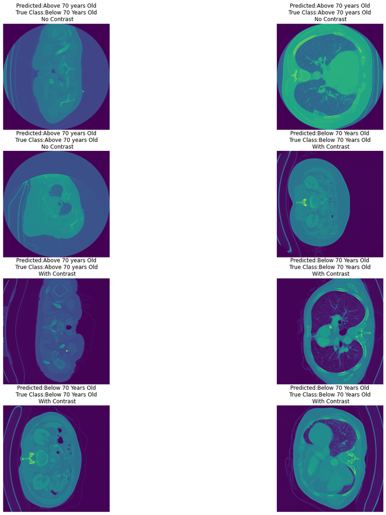

```python
visualize_model(model_resnet)
```

Even though this version of training, shows a great deal of accuracy, with some more trial and training, one could realize there is a great variance in test accuracy and perphaps then great deal of variance of model in relation to training data. The analysis needs more training points to reduce this variance and therefore not very wise to further analyze data with deep learning models.